# Corrupted Gauntlet Stats Fun

Tom Cox

2026-03-05

# Introduction

**Question:** How many Corrupted Gauntlet kills would you expect it would take to receive the necessary drops to craft a bow of faerdhinen and a full set of crystal armour? To answer this question, we must first understand more about how these drop rates work.

**Drop Rates:**

- Enhanced Crystal Weapon Seed: $\frac{1}{400}$
- Crystal Armour Seed: $\frac{1}{50}$ (need 6 for a full set)

```r
# Enhanced Crystal Weapon Seed drop rate
weapon_rate = 1 / 400

# Crystal Armour Seed drop rate
armour_rate = 1 / 50
```

[figure not shown]

(Image source: [OSRS Wiki](https://oldschool.runescape.wiki/index.php?curid=226618))

# Enhanced Crystal Weapon Seed

[figure not shown]

#### Average Kill Count

Let’s start with a more simple question: what is the number of kills you would expect it would take to receive a single enhanced crystal weapon seed? In other words, what is the **expected** number of trials (**Kill Count**) for the **average player** to receive a single drop of the weapon seed?

Before we can answer that, we must first answer the question of how many **failed** trials would you expect before the **first successful** one? Using a **Geometric Distribution**, we can calculate the **expected value** (mean) of failed trials before the first success. That is to say, we can calculate the average number of kills where we don’t receive a drop before the kill where the drop is expected as:

$$X \sim \text{Geom}(p) \implies E[X] =
\frac{1-p}{p}; \quad X \in \{0, 1, 2, \dots\}$$

**Where:**

- $X$: The number of failed trials (i.e., the number of kills before the kill that drops the targeted item).
- $p$: The probability of success on any individual, independent trial.

To find the number of **total trials** $(N)$ we expect to receive the drop, we simply add our 1 success back into the equation. This can then be simplified to:

$$N \sim \text{Geom}(p) \implies E[N] =
\frac{1-p}{p} + 1 = \frac{1}{p}; \quad N \in \{1, 2, 3, \dots\}$$

**Where:**

- $N$: The number of trials (i.e., the total kill count).

And indeed, plugging in our probability of $\frac{1}{400}$ provides us with the number of KC we can expect it to take to receive 1 enhanced crystal weapon seed:

$E[N] = \frac{1}{\frac{1}{400}} = \frac{400}{1} = 400$

```r
p = weapon_rate # 1/400 or 0.25% Chance
(1 / p) # Mean n
```

```
## [1] 400
```

This formula serves to prove a common intuition: if an item has a $\frac{1}{400}$ drop rate, the average player will get it in 400 kills.

#### Kill Count for a 50% Chance

But what if we wanted to know how many kills was required to have a **50% (median) chance** at a weapon seed drop? To calculate the number of failed trials (before the successful trial) needed to reach a cumulative probability $(q)$, we use an **Inverse Cumulative Distribution Function** (also known as a **Quantile Function**) for the geometric distribution.

Traditionally, the **Geometric Distribution** measures the number of **failures** that occur before the first success. The quantile function for this looks like:

$$X \sim \text{Geom}(p) \implies Q_X(q) =
F_X^{-1}(q) = \left\lceil \frac{\ln(1-q)}{\ln(1-p)} \right\rceil -
1$$
However, we don’t just track our failures, we track our total trials (kill count) which includes the kill we receive the drop (a success). To calculate total kill count $(n)$ rather than failures, we augment this formula into what is sometimes referred to as a **Shifted Geometric Distribution**.

We call this a **shifted** geometric distribution because we are calculating **trials** (KC), not **failures**. We can define trials as $N = X + successes$. Since we are only looking for the first success, we can state:

$$N \sim \text{Geom}(p) \implies Q_N(q) =
F_N^{-1}(q) = F_X^{-1}(q) + 1 = \left\lceil \frac{\ln(1-q)}{\ln(1-p)}
\right\rceil$$

(**Note**: This shift also occurs for calculating $E[N]$ above, but the details are omitted and instead introduced here to simplify the introductory question. It’s worthwhile to note that some sources may define the shifted distribution as the standard distribution but measuring a different random variable, like we do here for $N$. While that can make things confusing, the main takeaway from this is just understanding the idea of the distribution and when it should be used.)

**Question:** How many Corrupted Gauntlet kills would it take to reach a **50% (median) chance** of getting an Enhanced crystal weapon seed drop?

$F_N^{-1}(0.5)= \left\lceil \frac{\ln(1-0.5)}{\ln(1-\frac{1}{400})} \right\rceil$ = 277

```r
qgeom(0.5, weapon_rate) + 1 # Remember, we add 1 because qgeom() measures failures, not trials
```

```
## [1] 277
```

While it may feel counter-intuitive or backwards to define the inverse CDF without ever introducing the formal CDF (And indeed, one could argue this should be included for a more holistic approach to the concepts covered here), in the interest of conciseness we will forgo covering the CDF for this distribution in this section. That being said, we can still plot a graph showing the CDF to better illustrate the accuracy of our quantile function, as well as to better visualize the shape of our distribution:

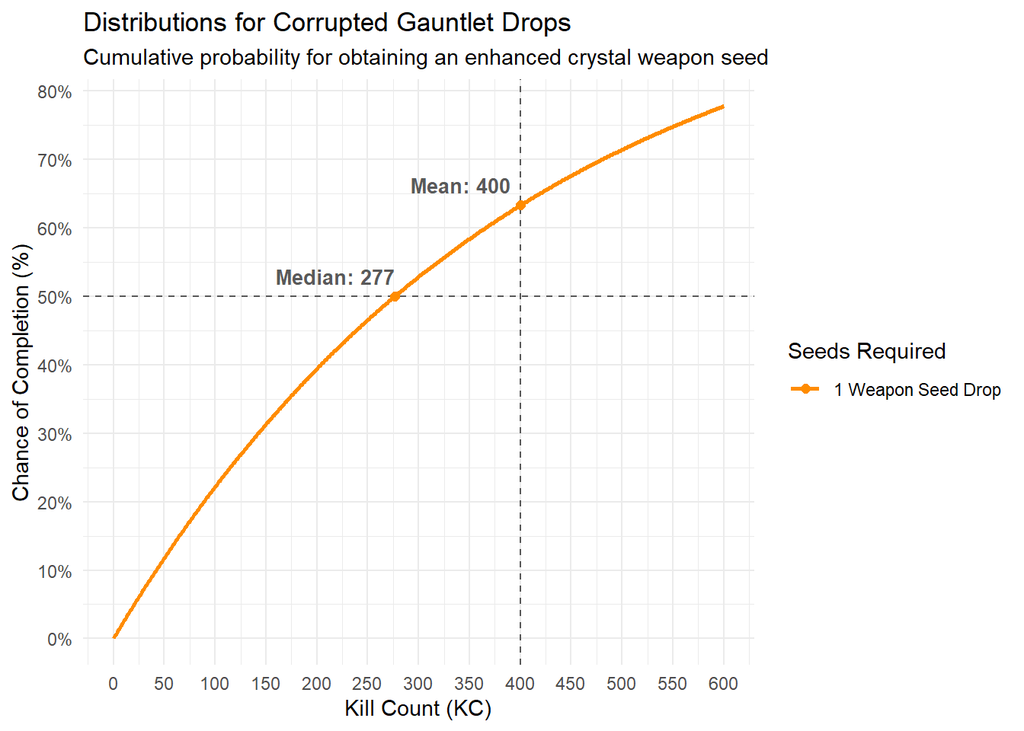

Something noteworthy about the window for this graph is that it cuts off at 600 KC. This is purely to keep the visual focused on our mean and median, as the distribution’s somewhat logarithmic curve drifts towards 2,000 to achieve a 99% chance of success.

(**Note**: See the Appendix for geometric distribution’s CDF formula, as well as plotted simulation data for p=1/400 that shows a wider graph detailing where the 99th percentile lies on this distribution for this p.)

[figure not shown]

(Image source: [OSRS Wiki](https://oldschool.runescape.wiki/index.php?curid=317876))

# Crystal Armour Seed

#### Average Kill Count

While the drop rate of a single crystal armour seed is $\frac{1}{50}$, we need **6** in total to craft a full set of armour. Using a **Negative Binomial Distribution**, we can calculate the **expected value** (mean) for the number of failures (i.e., KC before the kill that provides the drop) as:

$$X \sim \text{NegativeBinomial}(r,p)
\implies E[X] = \frac{r(1-p)}{p}$$
**Where:**

- $r$: The target number of successes.
- $p$: The probability of success on any individual, independent trial.

Just like with our quantile function, our function to find the expected value here is a measurement of failures, not trials. But also similar to the previous transformation, we can fix this by adding $successes$ (which is now represented by the variable $r$) into the equation. Therefore, we can transform this equation to measure the number of **trials** we can expect to receive the 6 drops as:

$$N \sim \text{NegativeBinomial}(r,p)
\implies E[N] = \frac{r(1-p)}{p} + r = \frac{r}{p}$$
And indeed, plugging in our number of successes needed and probability provides us with the number of KC we can expect it to take to receive 6 Crystal armour seeds:

$E[N] = \frac{6}{\frac{1}{50}} = 300$

```r
r = 6
p = 1 / 50 # 2% Chance
r / p # Mean n
```

```
## [1] 300
```

Now that we know the number of kills we would expect it would take to receive 6 armour seeds, we can move on to answer the same question we asked for the enhanced crystal weapon seed.

#### Kill Count for a 50% Chance

To answer this, we can use the **Cumulative Distribution Function** (CDF) of a **Negative Binomial Distribution**. In the interest of conciseness, we will forgo defining the conventional formulation modeling the number of failures ($X$). Instead, we will proceed directly to the parameterization for the total number of trials ($N$).

The CDF for a Negative Binomial Distribution expressed for **Kill Count (**$N$) calculates the probability that the $r^{th}$ success occurs on or before the $n^{th}$ attempt, and can be defined as:

$$N \sim \text{NegativeBinomial}(r,p)
\implies F(n) = P(N \le n) = \sum_{i=r}^{n} \binom{i-1}{r-1} p^r
(1-p)^{i-r}$$

**Where:**

- $n$: The target number of attempts (kill count)
- $r$: The target number of successes (e.g., 6 armour seeds)
- $p$: The probability of success on any individual trial (e.g., 1/50)

As you may have noticed, this function does not contain a parameter for the targeted quantile we want to define (0.5). To find the minimum number of kills $(n)$ required to have at least a 50% chance of obtaining 6 drops, we solve for the smallest integer $n\ge6$ that satisfies:

$$N \sim \text{NegativeBinomial}(r,p)
\implies F_N^{-1}(q) = \min \left\{ n \in \mathbb{Z} \mid n \ge r \text{
and } \sum_{i=r}^{n} \binom{i-1}{r-1} p^r (1-p)^{i-r} \ge q
\right\}$$
Unlike the geometric distribution, the cumulative distribution function (CDF) for the negative binomial distribution involves a **moving summation of combinations**. Because our target variable $n$ is the upper limit of this summation, there is no closed-form algebraic solution to isolate $n$. We cannot simply ‘solve for $n$’ using standard algebra as we have done before.

Instead, finding the required number of trials becomes a **computational search problem**. We can incrementally test integer values of $n$ until the cumulative probability crosses our 50% threshold. Statistical software like R can easily handle this numerical search with it’s built-in function qnbinom() (Notice how this looks similar to our qgeom() function from before?).

```r
qnbinom(0.5, 6, 1/50) + 6 # Adding our 6 "successes"
```

```
## [1] 284
```

```r
# pnbinom(284-6, 6, 1/50) # Confirms this is correct
```

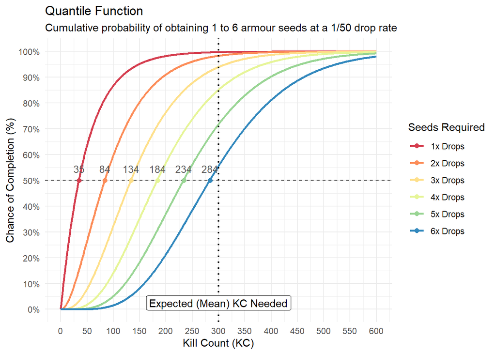

While our **expected value** tells us that the overall average to complete the armour set is 300 KC, the actual halfway point (**median**) is slightly lower, at 284 KC. This happens because the Negative Binomial distribution is right-skewed. There is a hard physical limit on how lucky a player can be: it is impossible to get 6 seeds in fewer than 6 kills. However, there is absolutely no limit on how unlucky a player can be. The small percentage of players who go exceptionally “dry” (e.g., taking 800+ KC to finish the set) pull the overall statistical average upward (i.e., to the right). As a result, more than 50% of players will actually complete their armour set before ever reaching the expected 300 KC.

[figure not shown]

(Image source: [OSRS Wiki](https://oldschool.runescape.wiki/index.php?curid=376376))

# Both Drops

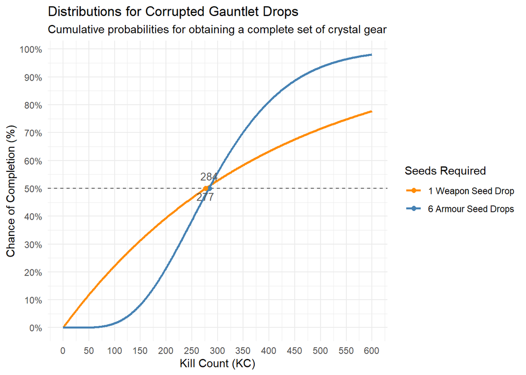

**Question:** Now that we can observe both distributions side-by-side, what do you think the **combined** distribution would look like? That is to say, what would the distribution look like for getting 1 crystal weapon seed drop **and** 6 armour seed drops?

Here’s a graph with 3 different example distributions. before scrolling down to see the answer, can you guess which one is the correct combined distribution?

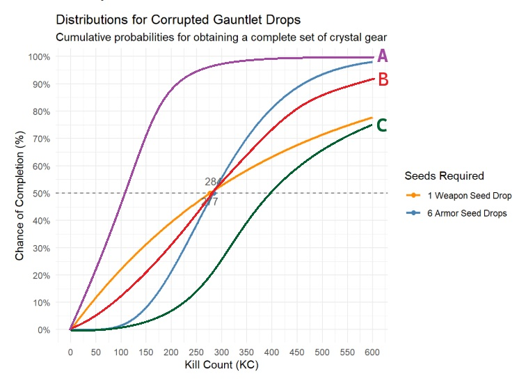

**Click to show plot!**

If you guessed **Distribution C**, then you were correct!

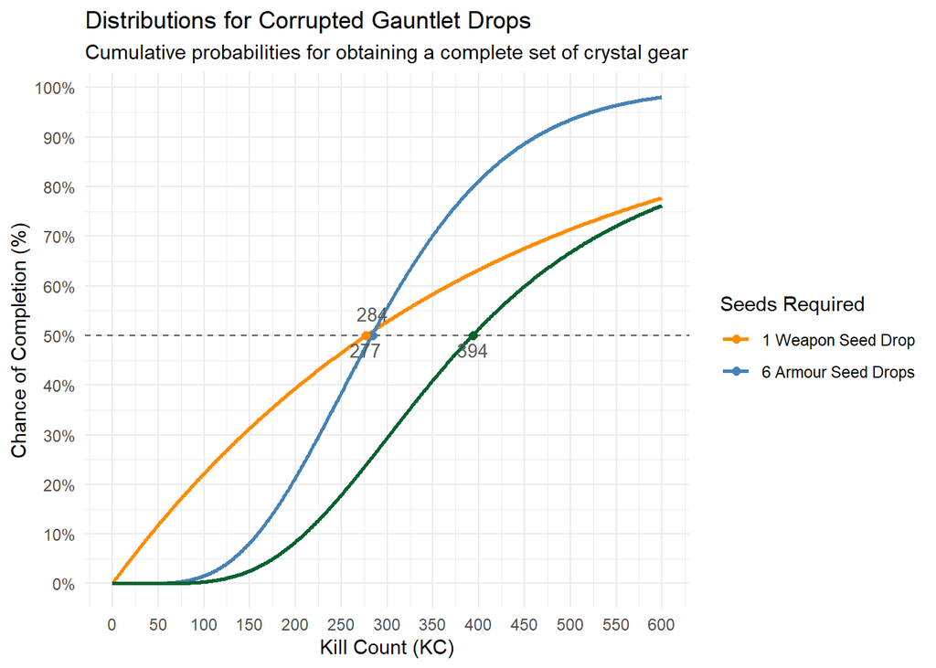

```r
r = 6
armour_rate = 1/50
weapon_rate = 1/400
kc_range = 0:10000  # make sure range is large enough to capture full distribution

# Compute the CDF values
cdf_vals = pnbinom(kc_range - r, size = r, prob = armour_rate) * pgeom(kc_range - 1, prob = weapon_rate)

# Convert CDF to PMF by differencing
pmf_vals = diff(c(0, cdf_vals))

# Verify it sums to ~1 (if not, extend kc_range)
sum(pmf_vals)
```

```
## [1] 1
```

[output not shown]

[figure not shown]

```r
# plot(pmf_vals)

# Compute mean and variance
mean_val = sum(kc_range * pmf_vals)
variance_val = sum((kc_range^2) * pmf_vals) - mean_val^2
sd_val = sqrt(variance_val)

cat("Mean:", mean_val, "\nVariance:", variance_val, "\nStd Dev:", sd_val)
```

[output not shown]

(Image source: [OSRS Wiki](https://oldschool.runescape.wiki/index.php?curid=226854))

# Appendix

## Geometric Distribution

### Introduction

A Geometric Distribution models the number of failures that occur before the first success in a sequence of independent Bernoulli trials (trials with only two outcomes: success or failure).

$$X \sim Geometric(p)$$

**Where:**

- $X$: The random variable representing the number of failures before the first success.
- $p$: The probability of success for each independent trial.
- **Trial**: Each trial is independent, meaning the outcome of one roll does not affect the next (this is known as the “memoryless” property of a given distribution).

**Example:** Pretend you are rolling a die until you see a 6, the **Geometric Distribution** tells you how likely you are to fail 0 times (first roll is a 6), 1 time (second roll is a 6), and so on.

### Helpful Definitions and Formulae

Geometric Distribution Reference Guide

| Property | Description | Failures $(X \in \{0, 1, \dots\})$ | Total Trials $N \in \{1, 2, \dots\})$ | R Code (for $N$) |
| --- | --- | --- | --- | --- |
| PMF $P(K=k)$ | Probability of success on **exactly** trial $k$. | $(1-p)^k p$ | $(1-p)^{k-1} p$ | `dgeom(k - 1, p)` |
| CDF $P(K \le k)$ | Probability of success **on or before** trial $k$. | $1 - (1-p)^{k+1}$ | $1 - (1-p)^k$ | `pgeom(k - 1, p)` |
| Mean $E[K]$ | The average number of trials expected for a success. | $\frac{1-p}{p}$ | $\frac{1}{p}$ | `1 / p` |
| Variance $Var(K)$ | The ‘spread’ or consistency of successes. | $\frac{1-p}{p^2}$ | $\frac{1-p}{p^2}$ | `(1 - p) / p^2` |
| Quantile $Q_K(q) \; , \; F_K^{-1}(q)$ | Trials required to reach a specific **$q$%** chance. | $\lceil \frac{\ln(1-q)}{\ln(1-p)} \rceil - 1$ | $\lceil \frac{\ln(1-q)}{\ln(1-p)} \rceil$ | `qgeom(q, p) + 1` |

### Helpful Visualizations

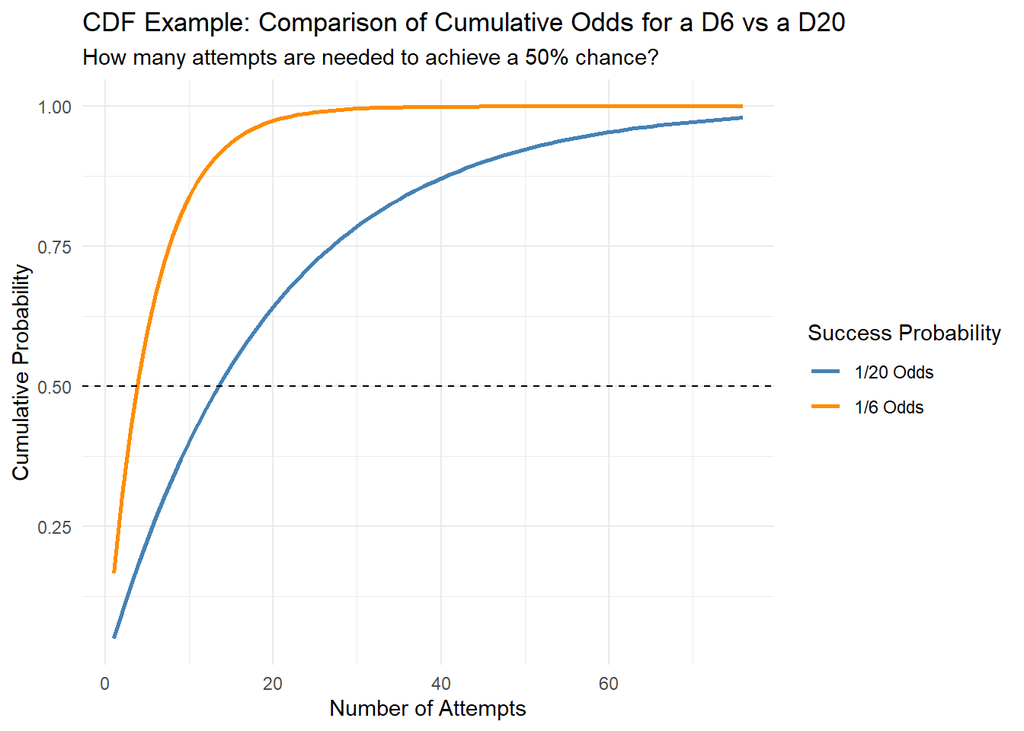

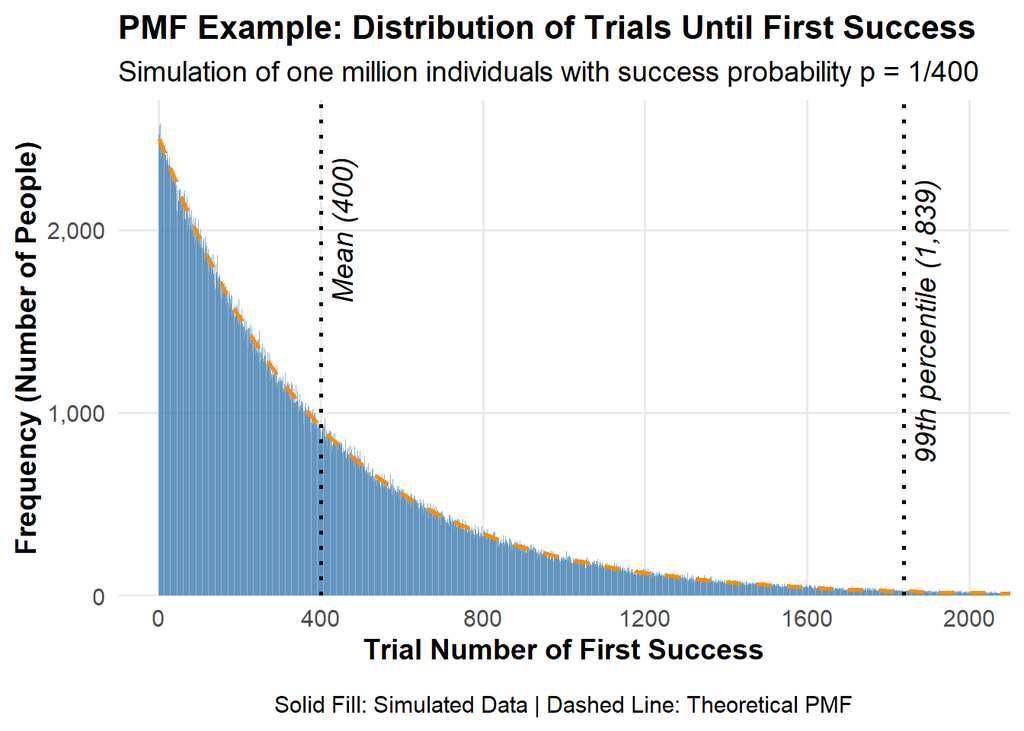

WORK IN PROGRESS

## Negative Binomial Distribution

# References

- Wikipedia for distribution formulae
- OSRS wiki for drop rates, images
- Gamecube Jona’s CG Video for inspiration

## Notes

**Broadly speaking, which distribution should you use?**

- Use **Binomial** if you have a set number of **attempts** and want to count **successes**.
- Use **Negative Binomial** if you have a set number of **successes** and want to count **attempts**.
- Use **Geometric** if you are only looking for the **first success** and want to count **attempts**.

[figure not shown]

(Image source: [OSRS Wiki](https://oldschool.runescape.wiki/index.php?curid=260313))

.

.

.

.

.

.

.